# COMPSCIX 415.2 Homework 1

## Aesthetic Mappings (3.3.1):

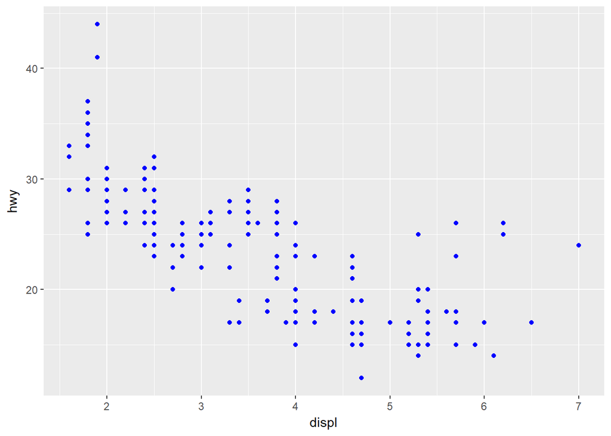

```r
ggplot(data = mpg) +
  geom_point(mapping = aes(x = displ, y = hwy), color = "blue")
```

- In order to the set the point’ color to be blue, use the manual setting method of passing the color = “blue” as an arugument to geom_function like below:

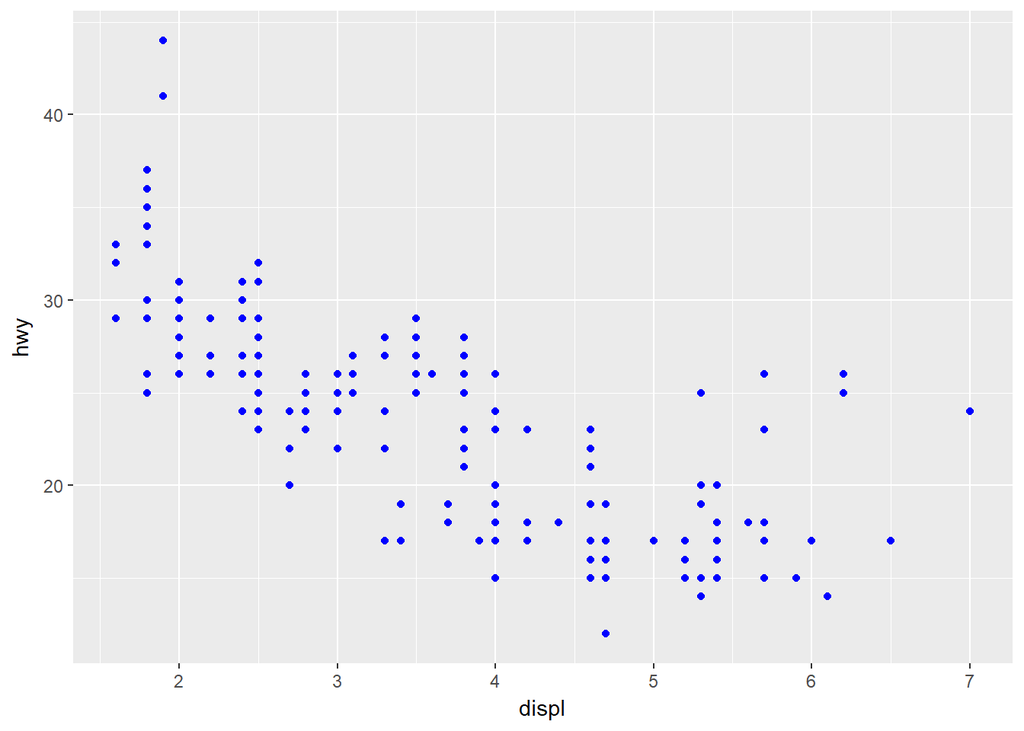

Correct way to manually set the color of points in scatterplot

```r
ggplot(data = mpg) +
  geom_point(mapping = aes(x = displ, y = hwy), color = "blue")
```

```r
mpg
```

```
## # A tibble: 234 x 11
##    manufacturer model    displ  year   cyl trans   drv     cty   hwy fl
##    <chr>        <chr>    <dbl> <int> <int> <chr>   <chr> <int> <int> <chr>
##  1 audi         a4        1.80  1999     4 auto(l~ f        18    29 p
##  2 audi         a4        1.80  1999     4 manual~ f        21    29 p
##  3 audi         a4        2.00  2008     4 manual~ f        20    31 p
##  4 audi         a4        2.00  2008     4 auto(a~ f        21    30 p
##  5 audi         a4        2.80  1999     6 auto(l~ f        16    26 p
##  6 audi         a4        2.80  1999     6 manual~ f        18    26 p
##  7 audi         a4        3.10  2008     6 auto(a~ f        18    27 p
##  8 audi         a4 quat~  1.80  1999     4 manual~ 4        18    26 p
##  9 audi         a4 quat~  1.80  1999     4 auto(l~ 4        16    25 p
## 10 audi         a4 quat~  2.00  2008     4 manual~ 4        20    28 p
## # ... with 224 more rows, and 1 more variable: class <chr>
```

3. Mapping a continuous variable to Color property will display the variations of values using different saturations of blue, whereas mapping a categorical variable to Color will display distinct values of the property in different colors.

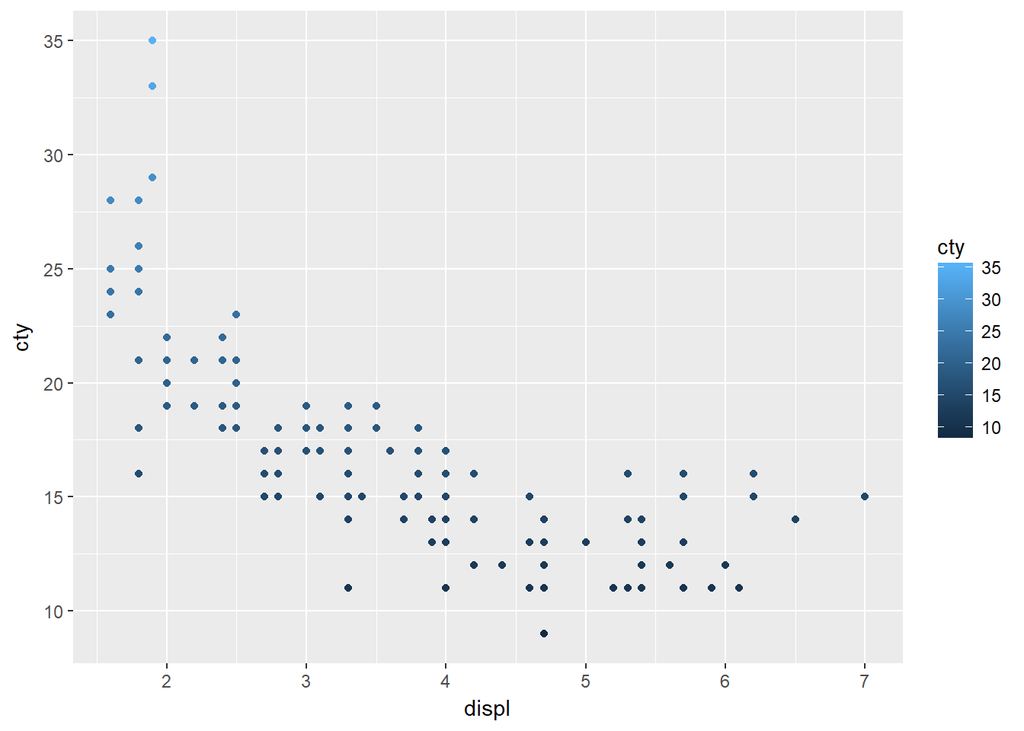

Mapping a continuous variable to Color (displ vs cty)

```r
ggplot(data=mpg) +
  geom_point(mapping = aes(x=displ, y=cty, color=cty))
```

- Mapping a continuous variable to size property will map the value to area of the mark. Any ordered continuous variable is suitable to show the variation using size property.

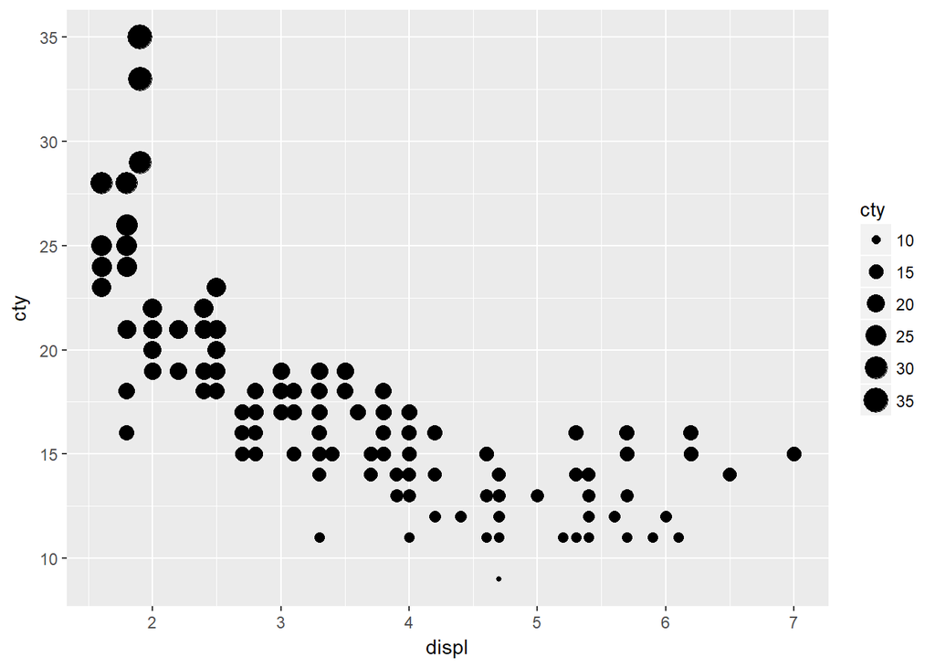

Mapping a continuous variable to Size (displ vs cty)

```r
ggplot(data=mpg) +
  geom_point(mapping = aes(x=displ, y=cty, size=cty))
```

- Shapes cannot be mapped using a continous variable as they cannot be ordered.

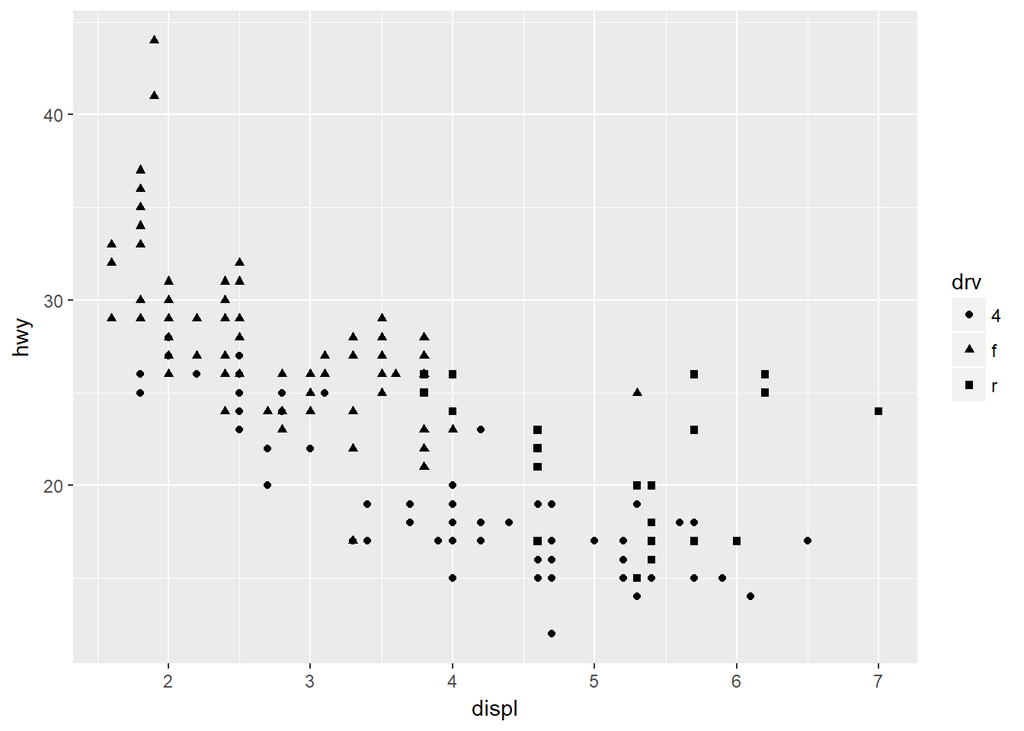

Mapping a discrete variable to Shape (displ vs hwy)

```r
ggplot(data=mpg) +
  geom_point(mapping = aes(x=displ, y=hwy, shape=drv))
```

4. Mapping same variable to multiple aesthetics will work just fine. This will give more visual cues to differentiate things from having a very slight variation between different values (ex: when color uses two or more colors of same with a slight variation in the saturation.)

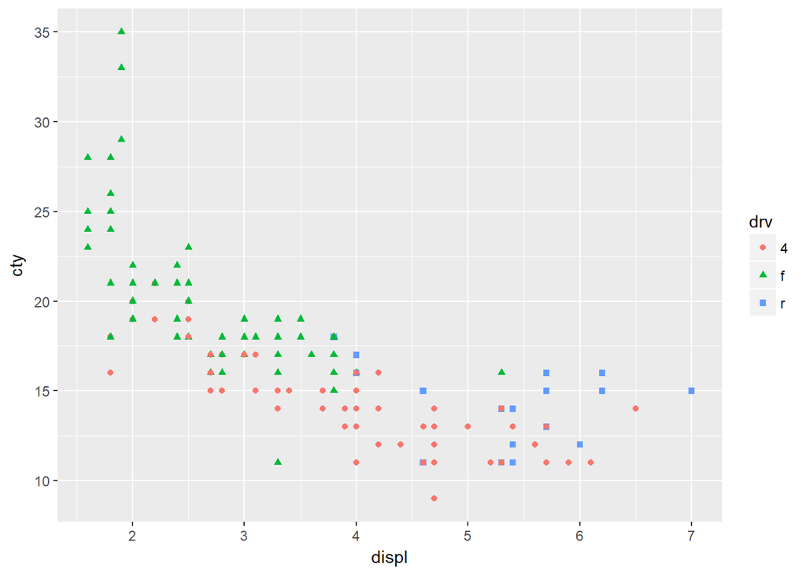

Using multiple aesthetics to same variable

```r
ggplot(data=mpg) +
  geom_point(mapping = aes(x=displ, y=cty, shape=drv, color=drv))
```

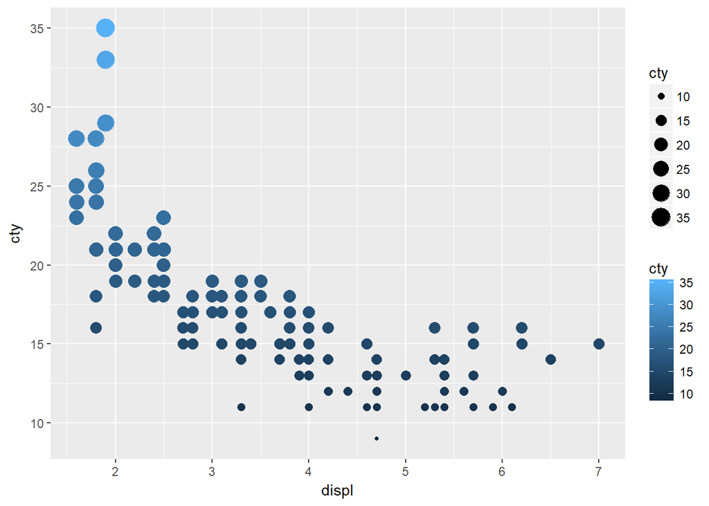

Using multiple aesthetics to same variable

```r
ggplot(data=mpg) +
  geom_point(mapping = aes(x=displ, y=cty, size=cty, color=cty))
```

5. Stroke aesthetic modifies the width of the border of shape according to the value provided. This can be used with all those shapes with a border, which are the following: 21, 22, 23, 24. Using stroke with shape, colour & fill property we can colour the inside and outside of the shape with different colours.

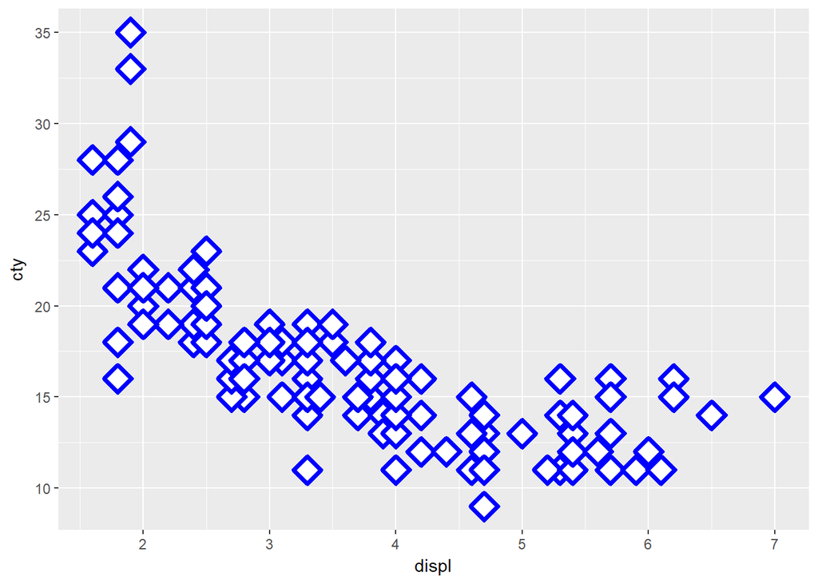

Using stroke property to geom_points

```r
ggplot(data = mpg) +
  geom_point(mapping = aes(x=displ, y=cty), shape=23, colour = "blue", fill = "white", size = 5, stroke = 2)
```

6. Mapping an aesthetic to an expression will evaluate the expression and uses the result as data to plot. Below is an example where displ < 5 will get evalated to a boolean value and is plotted.
- Mapping an aesthetic to anything else other than the variable column of property values will just plot the graph by default color without considering the value. I suppose doing this should technically throw an error.

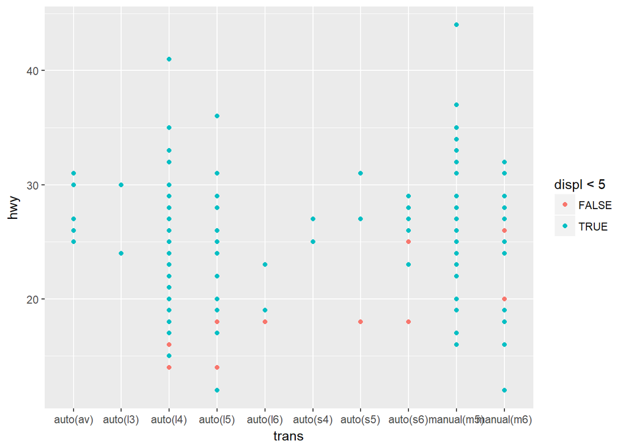

Mapping aesthetic to Expression & unknown variable

```r
ggplot(data=mpg) +
  geom_point(mapping = aes(x=trans, y=hwy, color= displ<5))
```

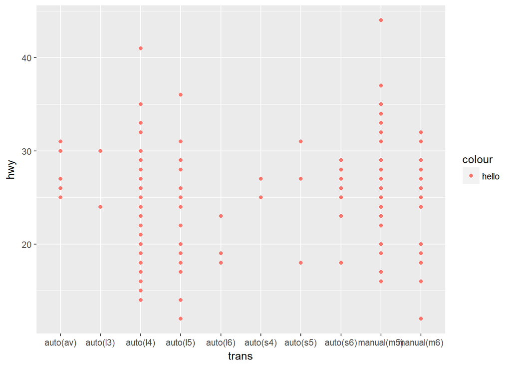

Mapping aesthetic to Expression & unknown variable

```r
ggplot(data=mpg) +
  geom_point(mapping = aes(x=trans, y=hwy, color= 'hello'))
```